# Business Statistics Mid-Term Assessment IB94X0 2024-2025 #1

5650766 - Dave Seiler

**Declaration of independence and use of AI and other tools:**

This is to certify that the work I am submitting is my own. All external references and sources are clearly acknowledged and identified within the contents. I am aware of the University of Warwick regulation concerning plagiarism and collusion.

No substantial part(s) of the work submitted here has also been submitted by me in other assessments for accredited courses of study, and I acknowledge that if this has been done an appropriate reduction in the mark I might otherwise have received will be made.

AI was used in the preparation of this work. It was used in the development of the code: It was used to provide example uses of functions or approaches to elements of the challenges which were then checked, interpreted and modified by me to be applicable to this data/report.

Additionally, translation and pharaphrasing tools were used to help to improve the given english answers or to translate some words from german to english.

# Section 1 - R-codes for data analysis

The code below performs the following analyses as required:

- Loading and checking the data for integrity and quality (additionally including data cleaning)
- Summary statistics (all data)
- Distribution plot of footfall by location (2019, all days)
- T-test to compare the footfall between Coney Street and Stonegate (2019, all days)
- T-test to compare the footfall between Coney Street and Stonegate (2019, weekends)
- Recommendations on given questions

## Data dictionary

The data used for the following analyses originates from cameras that automatically measure footfall in York.

The dataset variables are described in the following table:

| Variable | Description |
| --- | --- |
| Date | Calendar day of the footfall count |
| SiteName | Location of recording (in this case: York) |
| LocationName | Street name of the recording |
| WeekDay | Day of the week on which the recording was made |
| TotalCount | Number of people walking past the above mentioned locations (measured by cameras) |
| Recording_ID | ID-number of the camera recording |

## Pre-work

```r
# Load libraries
library(tidyverse)
library(DT) # To create better readable tables

# Set output width
options(width=100)

# Deactivate the scientific number notation
options(scipen = 999)

# Set the working directory
setwd("C:/Users/daves/OneDrive/Desktop/test/5650766")
```

## Data import

```r
footfall_data <- read_csv("York_Footfall_data.csv")
```

## Data overview

```r
head(footfall_data)
```

```
## # A tibble: 6 × 6
##   Date       SiteName LocationName             WeekDay  TotalCount Recording_ID
##   <date>     <chr>    <chr>                    <chr>         <dbl>        <dbl>
## 1 2015-01-01 York     Church Street            Thursday       1952       375836
## 2 2015-01-01 York     Coney Street             Thursday      12220       724862
## 3 2015-01-01 York     Micklegate               Thursday       5559       451020
## 4 2015-01-01 York     Parliament Street at M&S Thursday       7802       523989
## 5 2015-01-01 York     Stonegate                Thursday      14004       382272
## 6 2015-01-02 York     Church Street            Friday         3451       464381
```

## Integrity & Quality check

**Specification check:**

```r
spec(footfall_data)
```

*All data types are ok.*

**Duplicate check:**

```r
sum(duplicated(footfall_data %>% select(-Recording_ID))) # We exclude the ID variable for the check
```

```
## [1] 0
```

*We do not have any duplicates in the data.*

**Check data set for missing values:**

```r
sapply(footfall_data, function(x) sum(is.na(x)))
```

```
##         Date     SiteName LocationName      WeekDay   TotalCount Recording_ID
##            0            0            0            0           10          100
```

*We have 10 missing values in “TotalCount” and 100 missing values in “Recording_ID”.*

**Examine missing values of the variable “TotalCount”:**

```r
# Missing values:
footfall_data[is.na(footfall_data$TotalCount), ]
```

```
## # A tibble: 10 × 6
##    Date       SiteName LocationName  WeekDay   TotalCount Recording_ID
##    <date>     <chr>    <chr>         <chr>          <dbl>        <dbl>
##  1 2016-01-01 York     Church Street Friday            NA       740520
##  2 2016-01-02 York     Church Street Saturday          NA       383723
##  3 2016-01-03 York     Church Street Sunday            NA       159607
##  4 2015-12-28 York     Church Street Monday            NA       915184
##  5 2015-12-29 York     Church Street Tuesday           NA       320075
##  6 2015-12-30 York     Church Street Wednesday         NA       686430
##  7 2015-12-31 York     Church Street Thursday          NA       187309
##  8 2016-01-04 York     Church Street Monday            NA       112285
##  9 2016-01-05 York     Church Street Tuesday           NA        35188
## 10 2016-01-06 York     Church Street Wednesday         NA       264689
```

```r
# Number of Church Street data with count values
nrow(footfall_data %>%
  filter(LocationName == "Church Street" & !is.na(TotalCount)))
```

```
## [1] 890
```

*For “Church Street” we have 890 complete rows and 10 with missing counts. We could contact the responsible parties to see if we can still retrieve the values for those days. However, since only 10 out of 900 days are affected, we will remove these rows using the following code.*

```r
# Remove all rows with missing values in the variable "TotalCount"
footfall_data <- footfall_data %>%
  filter(!is.na(TotalCount))
```

**Comment on the missing values in the variable “Recording_ID”:**

*As the “Recording_ID” variable serves no significant purpose in this context, we will exclude the column to simplify the dataset.*

```r
# Remove the column "Recording_ID"
footfall_data <- footfall_data %>%
  select(-Recording_ID)
```

**Check categorical data:**

```r
arrange(count(footfall_data, SiteName), desc(n))
```

```
## # A tibble: 1 × 2
##   SiteName     n
##   <chr>    <int>
## 1 York      8194
```

```r
arrange(count(footfall_data, LocationName), desc(n))
```

```
## # A tibble: 6 × 2
##   LocationName                 n
##   <chr>                    <int>
## 1 Coney Street              1826
## 2 Micklegate                1826
## 3 Stonegate                 1826
## 4 Parliament Street         1668
## 5 Church Street              890
## 6 Parliament Street at M&S   158
```

```r
arrange(count(footfall_data, WeekDay), desc(n))
```

```
## # A tibble: 7 × 2
##   WeekDay       n
##   <chr>     <int>
## 1 Friday     1172
## 2 Saturday   1172
## 3 Sunday     1172
## 4 Thursday   1172
## 5 Monday     1170
## 6 Tuesday    1170
## 7 Wednesday  1166
```

*The variables “SiteName” and “WeekDay” are fine as they are. For “SiteName,” we only have “York,” and for “WeekDay,” all seven days of the week are correctly represented with no additional entries due to spelling mistakes. However, for the “LocationName” variable, we will standardise the names of “Parliament Street at M&S” and “Parliament Street,” as they refer to the same location but are currently split into two different names (with “Parliament Street at M&S” used up to 2015-06-07, and “Parliament Street” from 2015-06-08).*

```r
# Street name standardisation
footfall_data <- footfall_data %>%
  mutate(LocationName = str_replace(LocationName,"Parliament Street at M&S","Parliament Street"))
```

**Some visuals to check the distribution of the data:**

Histograms:

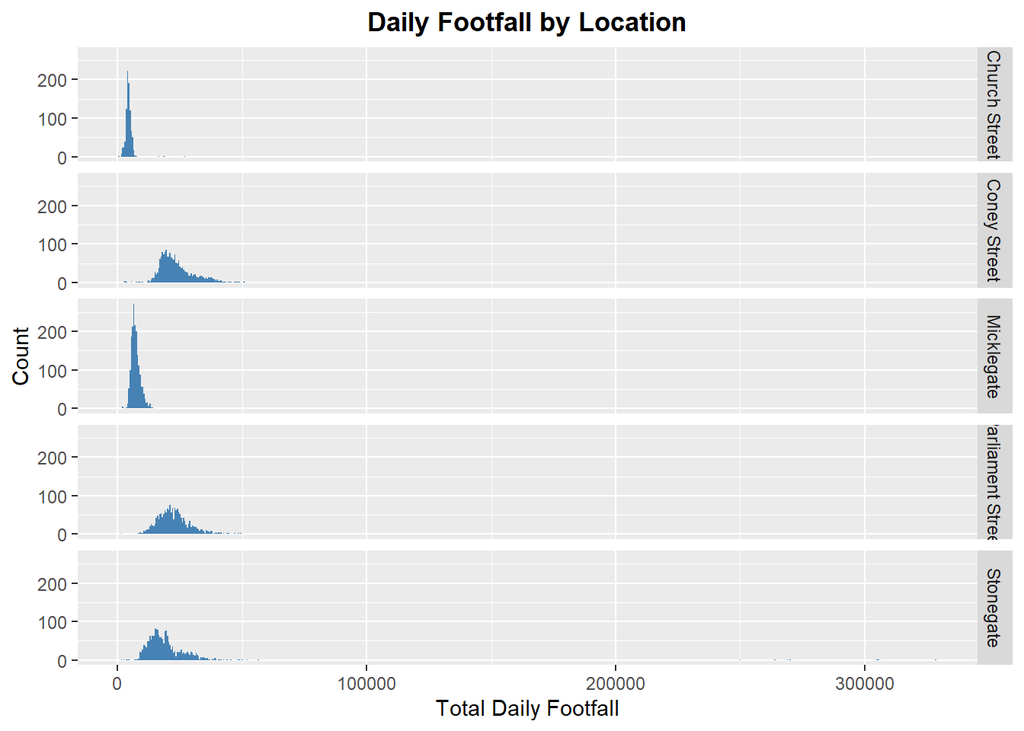

```r
ggplot(footfall_data) +
  geom_histogram(aes(x = TotalCount), fill = "steelblue", binwidth = 500) +
  facet_grid(LocationName ~ .) +
  labs(x = "Total Daily Footfall", y = "Count", title = "Daily Footfall by Location") +
  theme(plot.title = element_text(hjust = 0.5, face = "bold"))
```

Boxplots:

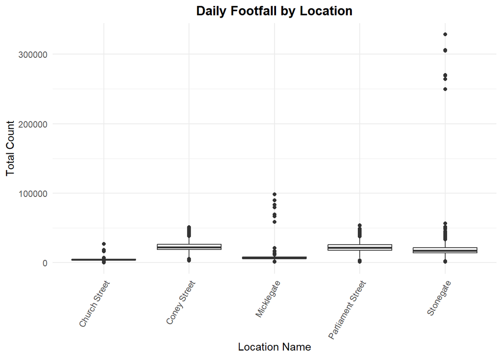

```r
ggplot(footfall_data) +
  geom_boxplot(aes(x = LocationName, y = TotalCount)) +
  theme_minimal() +
  labs(title = "Daily Footfall by Location", x = "Location Name", y = "Total Count") +
  theme(plot.title = element_text(hjust = 0.5, face = "bold"),
        axis.text.x = element_text(angle = 60, vjust = 1, hjust = 1))
```

*Both graphs (histogram and boxplot) show some extreme outliers at the locations “Micklegate” and “Stonegate”. – Further checks are required.*

Let’s take a look at those outliers:

```r
footfall_data %>%
  filter(LocationName == "Micklegate") %>%
  arrange(desc(TotalCount))
```

```
## # A tibble: 1,826 × 5
##    Date       SiteName LocationName WeekDay   TotalCount
##    <date>     <chr>    <chr>        <chr>          <dbl>
##  1 2017-12-22 York     Micklegate   Friday         98180
##  2 2017-12-21 York     Micklegate   Thursday       89530
##  3 2017-12-23 York     Micklegate   Saturday       83540
##  4 2017-12-20 York     Micklegate   Wednesday      79870
##  5 2017-12-18 York     Micklegate   Monday         69320
##  6 2017-12-19 York     Micklegate   Tuesday        66910
##  7 2017-12-24 York     Micklegate   Sunday         58920
##  8 2017-08-28 York     Micklegate   Monday         21082
##  9 2015-05-02 York     Micklegate   Saturday       17054
## 10 2016-08-28 York     Micklegate   Sunday         16237
## # ℹ 1,816 more rows
```

```r
footfall_data %>%
  filter(LocationName == "Stonegate") %>%
  arrange(desc(TotalCount))
```

```
## # A tibble: 1,826 × 5
##    Date       SiteName LocationName WeekDay   TotalCount
##    <date>     <chr>    <chr>        <chr>          <dbl>
##  1 2017-12-22 York     Stonegate    Friday        328310
##  2 2017-12-21 York     Stonegate    Thursday      305700
##  3 2017-12-23 York     Stonegate    Saturday      304890
##  4 2017-12-18 York     Stonegate    Monday        269930
##  5 2017-12-24 York     Stonegate    Sunday        269140
##  6 2017-12-20 York     Stonegate    Wednesday     264110
##  7 2017-12-19 York     Stonegate    Tuesday       249850
##  8 2017-12-09 York     Stonegate    Saturday       56371
##  9 2019-12-07 York     Stonegate    Saturday       51916
## 10 2017-12-02 York     Stonegate    Saturday       51833
## # ℹ 1,816 more rows
```

*Two things can be noted: Firstly, the values for both streets were recorded around Christmas 2017 and secondly, all values end in 0. This suggests either a one-off event, like a Christmas market or an error in the data (especially the fact that they all end in 0 is suspicious). In either case, these rows should be excluded to avoid skewing the analyses. We will do so in the next code chunk.*

```r
# Outlier count
footfall_data %>%
  summarise(Micklegate_count = sum(LocationName == "Micklegate" & TotalCount > 50000),
            Stonegate_count = sum(LocationName == "Stonegate" & TotalCount > 200000))
```

```
## # A tibble: 1 × 2
##   Micklegate_count Stonegate_count
##              <int>           <int>
## 1                7               7
```

```r
# Outlier removal
footfall_data <- footfall_data %>%
  filter(!(LocationName == "Micklegate" & TotalCount > 50000)) %>%
  filter(!(LocationName == "Stonegate" & TotalCount > 200000))
```

Let’s see how the histograms and boxplots look like after excluding the outliers:

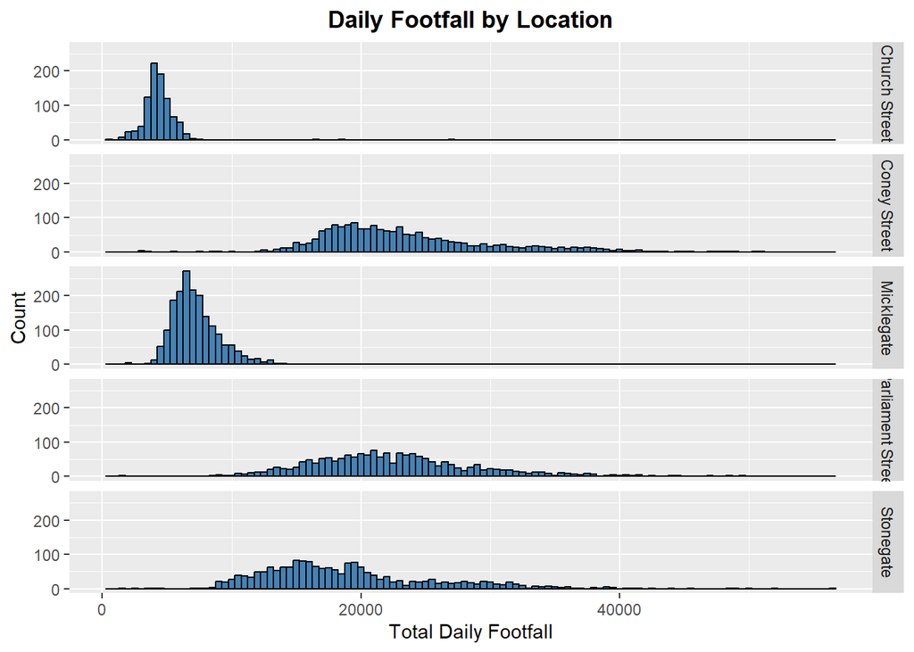

```r
( histogram_data_cleaned <- footfall_data %>%
    ggplot() + geom_histogram(aes(x = TotalCount), fill = "steelblue",
                              colour = "black", binwidth = 500) +
    facet_grid(LocationName ~ .) +
    labs(x = "Total Daily Footfall", y = "Count", title = "Daily Footfall by Location") +
    theme(plot.title = element_text(hjust = 0.5, face = "bold")) )
```

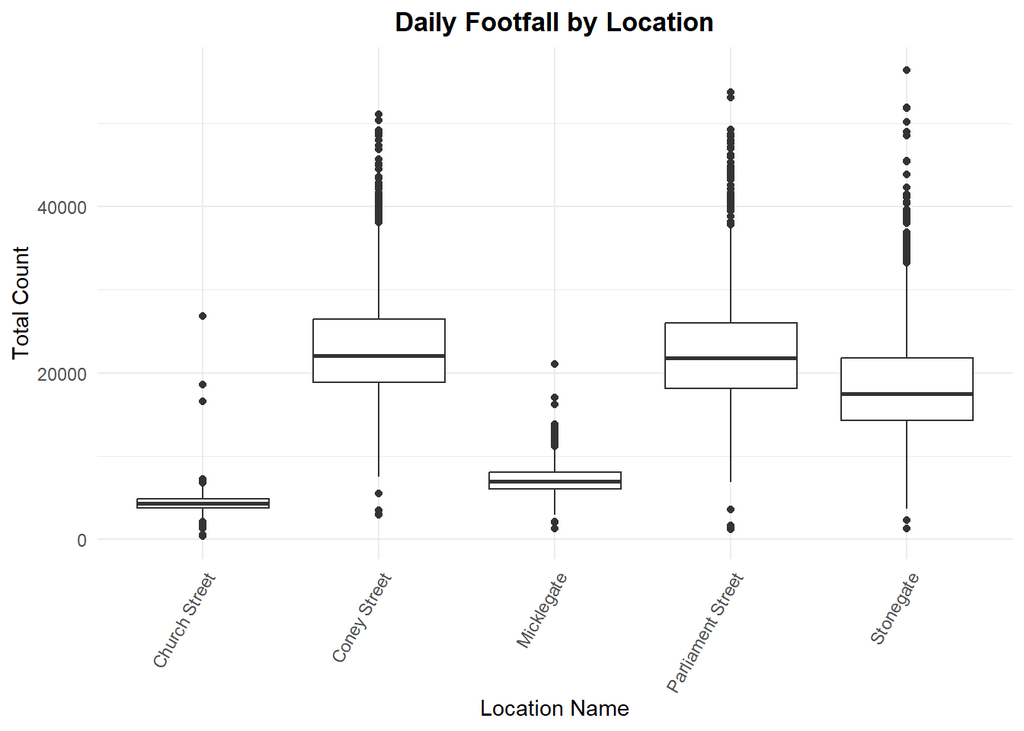

```r
( boxplot_data_cleaned <- footfall_data %>%
    ggplot() +
    geom_boxplot(aes(x = LocationName, y = TotalCount)) +
    theme_minimal() +
    labs(title = "Daily Footfall by Location", x = "Location Name", y = "Total Count") +
    theme(plot.title = element_text(hjust = 0.5, face = "bold"),
          axis.text.x = element_text(angle = 60, vjust = 1, hjust = 1)) )
```

*The graphs look much better now.*

## Summary-Table

```r
summary_statistics <- footfall_data %>%
    group_by(LocationName) %>%
    summarise(
        first_day = min(Date, na.rm = TRUE),
        last_day = max(Date, na.rm = TRUE),
        mean = round(mean(TotalCount, na.rm = TRUE),0),
        sd=round(sd(TotalCount, na.rm=TRUE),0),
        max=max(TotalCount, na.rm=TRUE),
        min=min(TotalCount, na.rm=TRUE))

datatable(summary_statistics, options = list(scrollX = TRUE))
```

|  | LocationName | first_day | last_day | mean | sd | max | min |
| --- | --- | --- | --- | --- | --- | --- | --- |
| 1 | Church Street | 2015-01-01 | 2017-06-18 | 4352 | 1389 | 26848 | 402 |
| 2 | Coney Street | 2015-01-01 | 2019-12-31 | 23507 | 6608 | 51050 | 2960 |
| 3 | Micklegate | 2015-01-01 | 2019-12-31 | 7215 | 1807 | 21082 | 1309 |
| 4 | Parliament Street | 2015-01-01 | 2019-12-31 | 22614 | 6714 | 53749 | 1227 |
| 5 | Stonegate | 2015-01-01 | 2019-12-31 | 18883 | 6753 | 56371 | 1297 |

*The table above shows that footfall on “Church Street” was only measured from 2015 to mid-2017, whereas all other streets were measured until the end of 2019. The highest mean is recorded at “Coney Street”, closely followed by “Parliament Street”. “Stonegate” also has a high mean, though slightly lower than the previously mentioned streets. Later, we will conduct t-tests to assess the differences in means for the 2019 data for significance.*

## Filter 2019 Data

```r
footfall_data_2019 <- footfall_data %>%
  filter(format(Date, "%Y") == "2019")
```

## Distribution-Plot

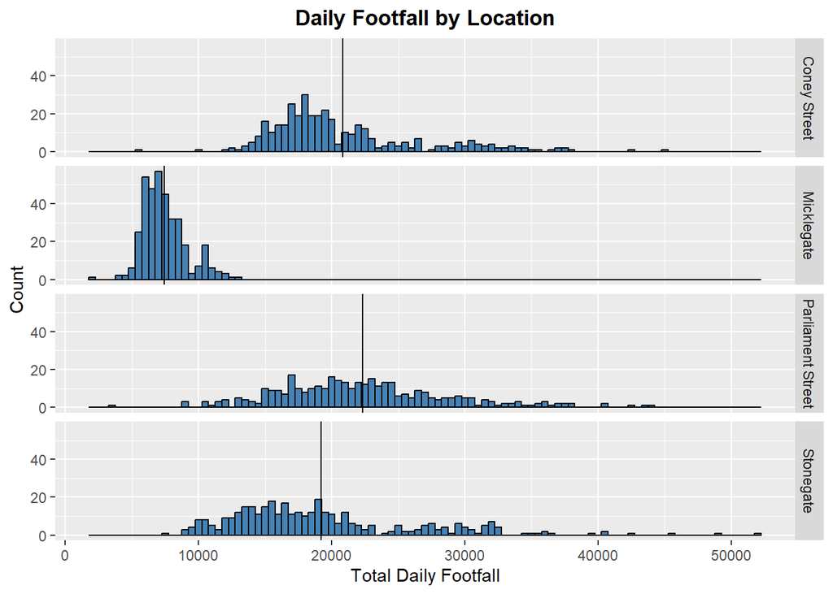

```r
mean_footfall_by_location <- footfall_data_2019 %>%
  group_by(LocationName) %>%
  summarise(frequency=n(),
            mean=mean(TotalCount))

( histogram_2019_by_location <- ggplot(footfall_data_2019) +
  geom_histogram(aes(x = TotalCount), fill = "steelblue", binwidth = 500, color = "black") +
  geom_vline(data=mean_footfall_by_location, mapping=aes(xintercept=mean), col="black") +
  facet_grid(LocationName ~ .) +
  labs(x = "Total Daily Footfall", y = "Count", title = "Daily Footfall by Location") +
                                            theme(plot.title = element_text(hjust = 0.5,
                                                  face = "bold")) )
```

*Apart from “Micklegate”, the variation is fairly wide. “Parliament Street” seems to have the highest average, closely followed by “Coney Street” (We will later test the differences in means for significance).*

**Additional visualisation:**  
Since we previously created boxplots for all data and found discrepancies (similar to those in the histogram), we will briefly illustrate this again, now using the data for 2019.

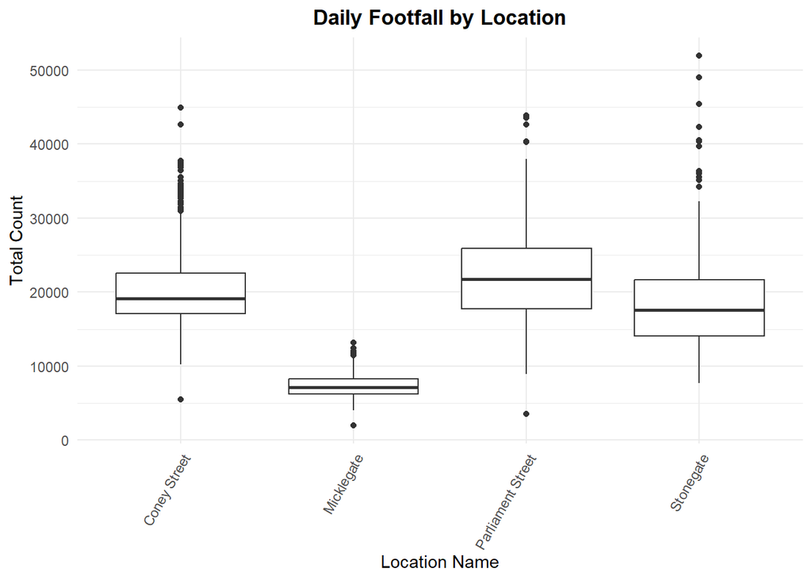

```r
( boxplot_2019_by_location <- ggplot(footfall_data_2019, aes(x = LocationName, y = TotalCount)) +
  geom_boxplot() +
  theme_minimal() +
  labs(title = "Daily Footfall by Location", x = "Location Name", y = "Total Count") +
  theme(plot.title = element_text(hjust = 0.5, face = "bold"),
        axis.text.x = element_text(angle = 60, vjust = 1, hjust = 1)) )
```

*It provides a similar view to the histograms shown earlier. Within the 2019 data, there don’t appear to be extreme outliers.*

## T-test to compare “Coney Street” with “Stonegate” (all days)

```r
t_test_1_data <- footfall_data_2019 %>%
  filter(LocationName == "Coney Street" | LocationName =="Stonegate")

( t_test_1_result <- t.test(TotalCount~LocationName, data=t_test_1_data) )
```

```
##
##  Welch Two Sample t-test
##
## data:  TotalCount by LocationName
## t = 3.3611, df = 699.18, p-value = 0.0008186
## alternative hypothesis: true difference in means between group Coney Street and group Stonegate is not equal to 0
## 95 percent confidence interval:
##   670.9189 2555.7989
## sample estimates:
## mean in group Coney Street    mean in group Stonegate
##                   20817.45                   19204.09
```

*The two-sample independent-sample $t-test$ reveals that the mean of “Coney Street” (20’817) and “Stonegate” (19’204) differ statistically significant. Confirming that “Coney Street” has a statistically significant higher mean footfall than “Stonegate” ($t(699.18) = 3.36$, $p < 0.001$).*

**Conclusion:** Considering the t-test results above, they should set up their stall on “Coney Street” for all days.

## T-test to compare “Coney Street” with “Stonegate” (weekends)

```r
t_test_2_data <- footfall_data_2019 %>%
  filter(LocationName == "Coney Street" | LocationName =="Stonegate") %>%
  filter(WeekDay == "Saturday" | WeekDay == "Sunday")

( t_test_2_result <- t.test(TotalCount~LocationName, data=t_test_2_data) )
```

```
##
##  Welch Two Sample t-test
##
## data:  TotalCount by LocationName
## t = -0.29072, df = 203.88, p-value = 0.7716
## alternative hypothesis: true difference in means between group Coney Street and group Stonegate is not equal to 0
## 95 percent confidence interval:
##  -2362.601  1755.409
## sample estimates:
## mean in group Coney Street    mean in group Stonegate
##                   25863.37                   26166.96
```

*The two-sample independent-sample $t-test$ reveals that the mean of “Coney Street” **on the weekend** (25’863) and “Stonegate” **on the weekend** (26’167) do **NOT** differ statistically significant ($t(203.88) = -0.29$, $p = 0.7716$).*

**Conclusion:** Considering the t-test results above, it doesn’t matter if they set up their stall on “Coney Street” or “Stonegate” **on the weekends**.

## Recommendations

A more detailed recommendation section is located at the end of the report for the management board. It summarises all conclusions above, provides information on an additional interesting location and offers suggestions on other factors to consider when choosing a location.

# Section 2 - Report

**Report date:** 2024-10-29, **Date of last update:** 2024-10-29

## Introduction, fundamentals and goal clarification

The following report presents the analyses requested by the board. The data used for this purpose contains information about the footfall from 2015 to 2019 in York, automatically counted using video cameras at different locations.

In the first part the report takes a look at all data (2015 to 2019) before the second part of the report focuses on the 2019 data to conduct more in-dept analyses and prepare suggestions on where to set up a stand ideally, which also **represents the main goal** of the report.

## Data Summary 2015 to 2019

```r
datatable(summary_statistics, options = list(scrollX = TRUE))
```

|  | LocationName | first_day | last_day | mean | sd | max | min |
| --- | --- | --- | --- | --- | --- | --- | --- |
| 1 | Church Street | 2015-01-01 | 2017-06-18 | 4352 | 1389 | 26848 | 402 |
| 2 | Coney Street | 2015-01-01 | 2019-12-31 | 23507 | 6608 | 51050 | 2960 |
| 3 | Micklegate | 2015-01-01 | 2019-12-31 | 7215 | 1807 | 21082 | 1309 |
| 4 | Parliament Street | 2015-01-01 | 2019-12-31 | 22614 | 6714 | 53749 | 1227 |
| 5 | Stonegate | 2015-01-01 | 2019-12-31 | 18883 | 6753 | 56371 | 1297 |

The summary statistics above provide an initial overview of the data from 2015 to 2019. Footfall on “Church Street” was only recorded from 2015 to mid-2017, while all other streets were measured through to the end of 2019. We won’t go into further detail here, as more precise analyses and graphs will follow for the 2019 data.

## Data Visualisation 2019

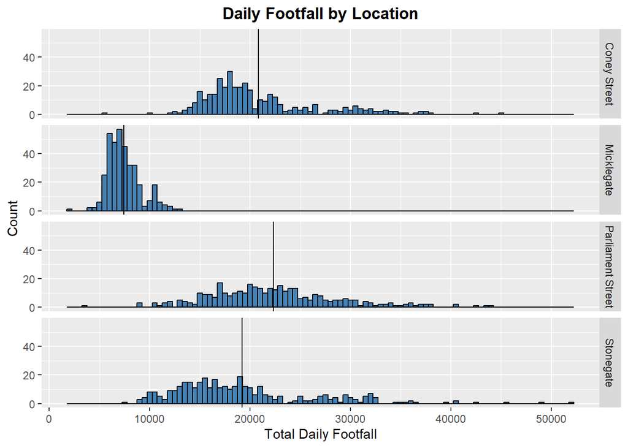

```r
histogram_2019_by_location
```

The various histograms suggest that “Micklegate” is likely the least attractive location for a stall, followed by “Stonegate.” “Coney Street” and “Parliament Street” appear to be the best options, with “Parliament Street” seeming slightly better. In the following, as requested by the board, “Coney Street” is compared with “Stonegate.” An additional analysis comparing “Coney Street” and “Parliament Street” can be found in the appendix.

## T-Tests and Results

To better determine the ideal location for a stall, the board requested a comparison between “Coney Street” and “Stonegate”, both for all days of the week and just for the weekends.

The following tests analyse whether there is a statistically significant difference in the mean footfall between “Coney Street” and “Stonegate” (for all days of the week and just weekends), helping to make a more informed decision about where to set up our stall to achieve the maximum footfall.

**Test 1:** Two-sample independent-sample t-test to compare the mean differences between “Coney Street” and “Stonegate” (all days).

```r
t_test_1_result
```

```
##
##  Welch Two Sample t-test
##
## data:  TotalCount by LocationName
## t = 3.3611, df = 699.18, p-value = 0.0008186
## alternative hypothesis: true difference in means between group Coney Street and group Stonegate is not equal to 0
## 95 percent confidence interval:
##   670.9189 2555.7989
## sample estimates:
## mean in group Coney Street    mean in group Stonegate
##                   20817.45                   19204.09
```

*The two-sample independent-sample $t-test$ reveals that the mean of “Coney Street” (20’817) and “Stonegate” (19’204) differ statistically significant. Confirming that “Coney Street” has a statistically significant higher mean footfall than “Stonegate” ($t(699.18) = 3.36$, $p < 0.001$).*

**Test 2:** Two-sample independent-sample t-test to compare the mean differences between “Coney Street” and “Stonegate” (weekend only).

```r
t_test_2_result
```

```
##
##  Welch Two Sample t-test
##
## data:  TotalCount by LocationName
## t = -0.29072, df = 203.88, p-value = 0.7716
## alternative hypothesis: true difference in means between group Coney Street and group Stonegate is not equal to 0
## 95 percent confidence interval:
##  -2362.601  1755.409
## sample estimates:
## mean in group Coney Street    mean in group Stonegate
##                   25863.37                   26166.96
```

*The two-sample independent-sample $t-test$ reveals that the mean of “Coney Street” **on the weekend** (25’863) and “Stonegate” **on the weekend** (26’167) do **NOT** differ significantly ($t(203.88) = -0.29$, $p = 0.7716$).*

## Recommendations

**Every day of the week:** If they want to set up their stall every day (on either “Coney Street” or “Stonegate”)*, they should go to “Coney Street”, which has a statistically significant higher mean footfall than “Stonegate”.

**Only at the weekend:** If they only want to set up their stall at the weekend, then it doesn’t really matter whether they do this at the “Coney Street” or “Stonegate” location, as the difference in average footfall is not statistically significant.

***Note:** In the appendix “Parliament Street” (22’328) is additionally tested against “Coney Street” (20’817), which would be an even more interesting alternative for an everyday stall. However, as this test was not requested by the board, it is added as an supplement so that it can be examined. (At the moment we do not know the reasons why they wanted to compare ONLY “Coney Street” and “Stonegate”).

## Final comment

**Note:** Of course, it is essential to first examine the customer group that frequents these locations and whether they align with our target audience. High traffic with the wrong audience would not provide us with any advantage.

## Appendix

**Additional test:** Two-sample independent-sample t-test to compare the mean differences between “Parliament Street” and “Coney Street”

```r
t_test_3_data <- footfall_data_2019 %>%
  filter(LocationName == "Coney Street" | LocationName =="Parliament Street")

( t_test_3_result <- t.test(TotalCount~LocationName, data=t_test_3_data) )
```

```
##
##  Welch Two Sample t-test
##
## data:  TotalCount by LocationName
## t = -3.3417, df = 720.69, p-value = 0.0008755
## alternative hypothesis: true difference in means between group Coney Street and group Parliament Street is not equal to 0
## 95 percent confidence interval:
##  -2397.1934  -622.8997
## sample estimates:
##      mean in group Coney Street mean in group Parliament Street
##                        20817.45                        22327.50
```

*If we additionally test the mean value of “Parliament Street” (22’328) against “Coney Street” (20’817) (all days of the week) we get the following result: The two-sample independent-sample $t-test$ reveals that the mean of “Parliament Street” (22’328) and “Coney Street” (20’817) differ statistically significant. Showing that “Parliament Street” has a statistically significant higher mean footfall than “Coney Street” ($t(720.69) = -3.34$, $p < 0.001$).*

*This would make “Parliament Street” the best option for an everyday stall and should definitely be taken into consideration by the board.*